# **Panorama da inflação**

Os principais índices de inflação do Brasil, apontam em março de 2021 um avanço da inflação de em média **1.58%**. Com esse resultado, no ano a inflação acumula uma variação média positiva de **3.18%**, e em 12 meses uma variação média acumulada de **14.71%**.

[output not shown]

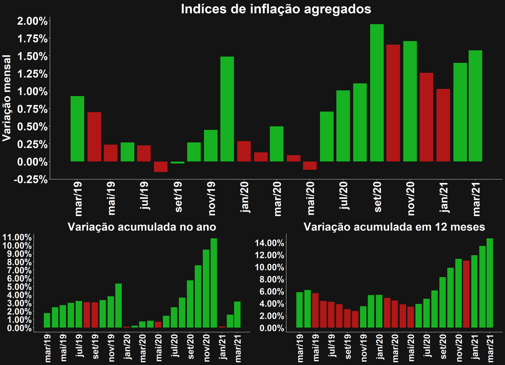

Índices selecionados para a média: IPCA, INPC e IGP-M.

# IPCA

|  | 03/2020 | 02/2021 | 03/2021 |
| --- | --- | --- | --- |
| Variação mensal | 0.07% | 0.86% | 0.93% |
| Variação acumulada no ano | 0.53% | 1.11% | 2.05% |
| Variação acumulada em 12 meses | 3.3% | 5.2% | 6.1% |

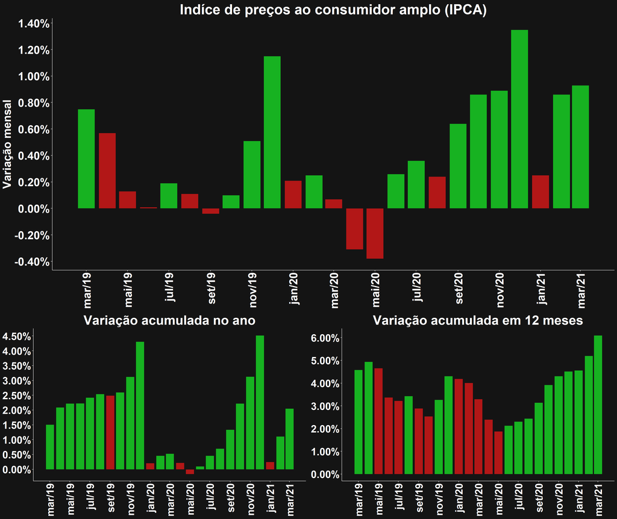

Os grupos que tiveram maior resultado positivo foram Transportes (3.81%) e Habitação (0.81%), e negativo Educação (-0.52%) e Comunicação (-0.07%).

|  | Variação mensal | Variação acumulada no ano | Peso mensal |
| --- | --- | --- | --- |
| Alimentação e bebidas | 0.13% | 1.42% | 21.15% |
| Habitação | 0.81% | 0.13% | 15.43% |
| Artigos de residência | 0.69% | 2.23% | 3.82% |
| Vestuário | 0.29% | 0.6% | 4.29% |
| Transportes | 3.81% | 6.61% | 20.23% |
| Saúde e cuidados pessoais | -0.02% | 0.92% | 13.12% |
| Despesas pessoais | 0.04% | 0.6% | 10.32% |
| Educação | -0.52% | 2.08% | 6.04% |
| Comunicação | -0.07% | -0.18% | 5.59% |

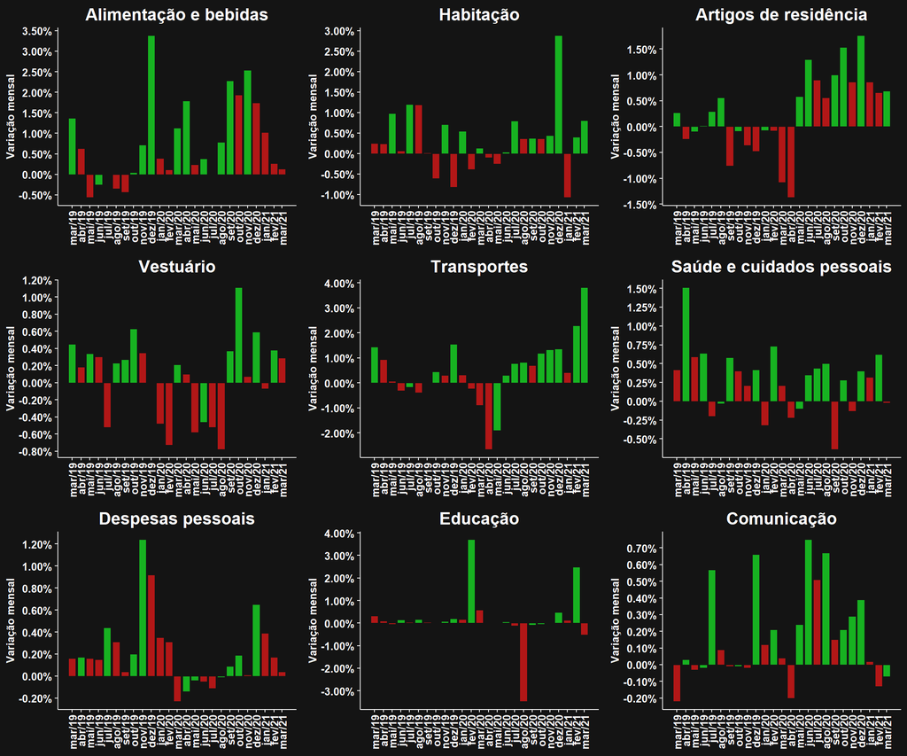

A nível de sub-itens os que mais influenciaram positivamente no resultado em relação ao seu peso foram Gasolina (11.26%%) e Etanol (12.59%%), e negativamente Tomate (-14.12%%) e Ensino superior (-1.75%%).

|  | Variação mensal | Variação acumulada no ano | Peso mensal |
| --- | --- | --- | --- |
| Gás de botijão | 4.98% | 11.56% | 1.17% |
| Etanol | 12.59% | 23.77% | 0.71% |
| Gasolina | 11.26% | 21.76% | 5.32% |
| Energia elétrica residencial | 0.76% | -5.56% | 4.27% |

|  | Variação mensal | Variação acumulada no ano | Peso mensal |
| --- | --- | --- | --- |
| Ensino superior | -1.75% | -0.83% | 1.77% |
| Tomate | -14.12% | -17.62% | 0.25% |
| Perfume | -2.25% | 1.3% | 1.06% |
| Batata-inglesa | -8.81% | -13.78% | 0.22% |

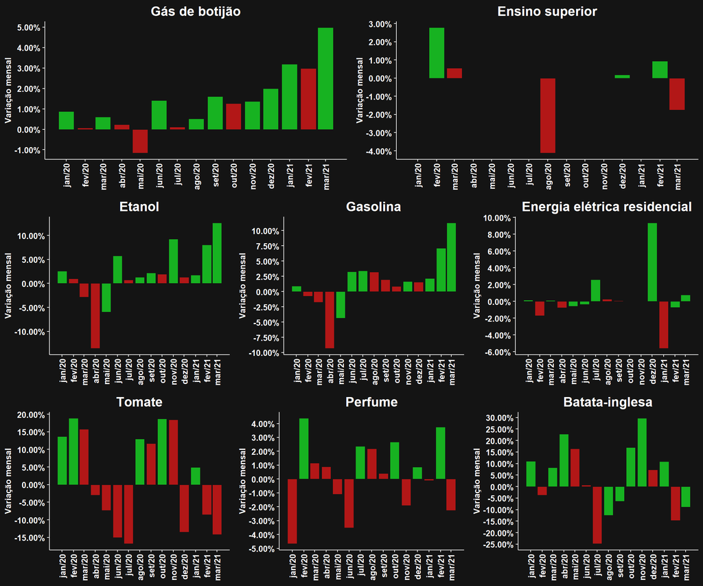

# INPC

O Indíce Nacional de Preços ao Consumidor (INPC) variou 0.86% em março, valor superior ao mesmo período do ano anterior quando apresentou uma taxa de 0.18%. Com esse resultado o indíce acumula no ano uma variação positiva de 1.96%, e em 12 meses uma variação positiva de 6.94%.

|  | 03/2020 | 02/2021 | 03/2021 |
| --- | --- | --- | --- |
| Variação mensal | 0.18% | 0.82% | 0.86% |
| Variação acumulada no ano | 0.54% | 1.09% | 1.96% |
| Variação acumulada em 12 meses | 3.31% | 6.22% | 6.94% |

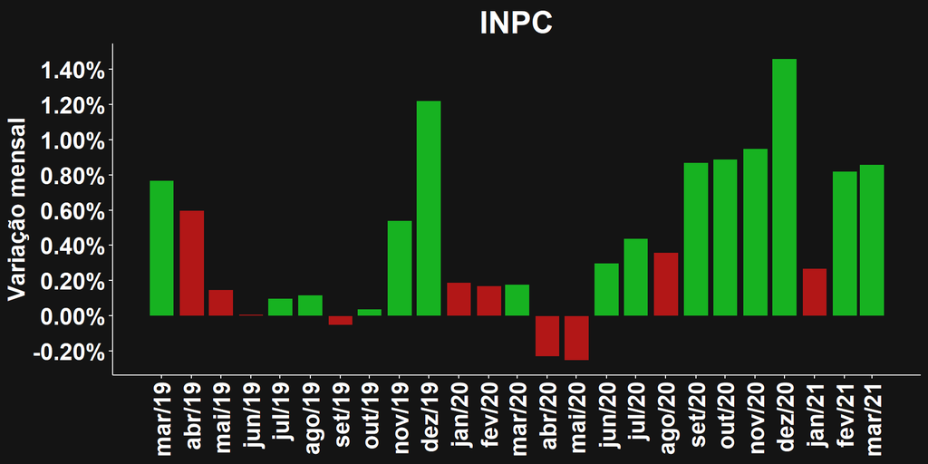

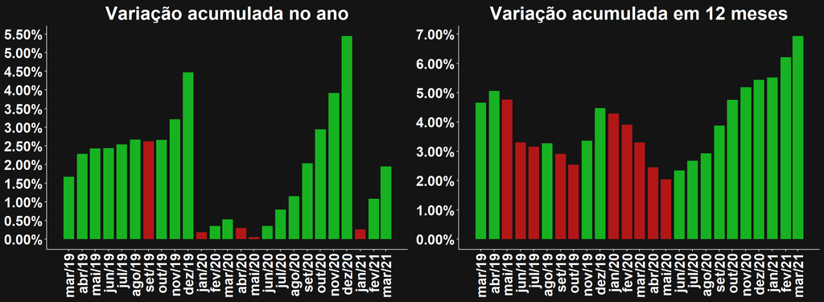

# IGP-M

O Indíce Geral de Preços de Mercado (IGP-M) variou 2.94% em março, valor superior ao mesmo período do ano anterior quando apresentou uma taxa de 1.24%. Com esse resultado o indíce acumula no ano uma variação positiva de 5.54%, e em 12 meses uma variação positiva de 31.1%.

|  | 03/2020 | 02/2021 | 03/2021 |
| --- | --- | --- | --- |
| Variação mensal | 1.24% | 2.53% | 2.94% |
| Variação acumulada no ano | 1.2% | 2.53% | 5.54% |
| Variação acumulada em 12 meses | 6.81% | 28.94% | 31.1% |

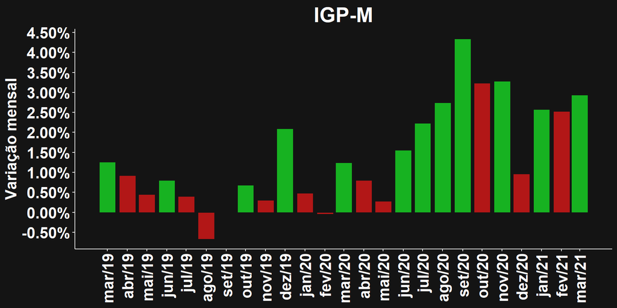

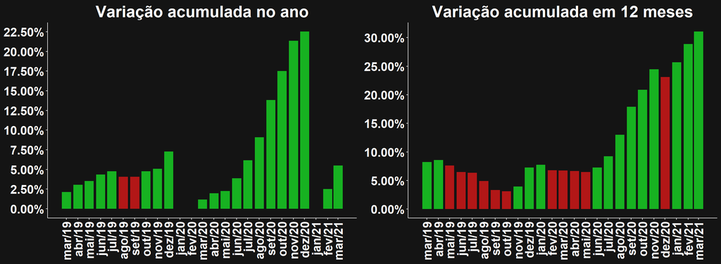

# IGP-DI

O Indíce Geral de Preços - Disponibilidade Interna (IGP-DI) variou 2.17% em março, valor superior ao mesmo período do ano anterior quando apresentou uma taxa de 1.64%. Com esse resultado o indíce acumula no ano uma variação positiva de 4.93%, e em 12 meses uma variação positiva de 30.63%.

|  | 03/2020 | 02/2021 | 03/2021 |
| --- | --- | --- | --- |
| Variação mensal | 1.64% | 2.71% | 2.17% |
| Variação acumulada no ano | 1.66% | 2.71% | 4.93% |
| Variação acumulada em 12 meses | 7.01% | 29.95% | 30.63% |

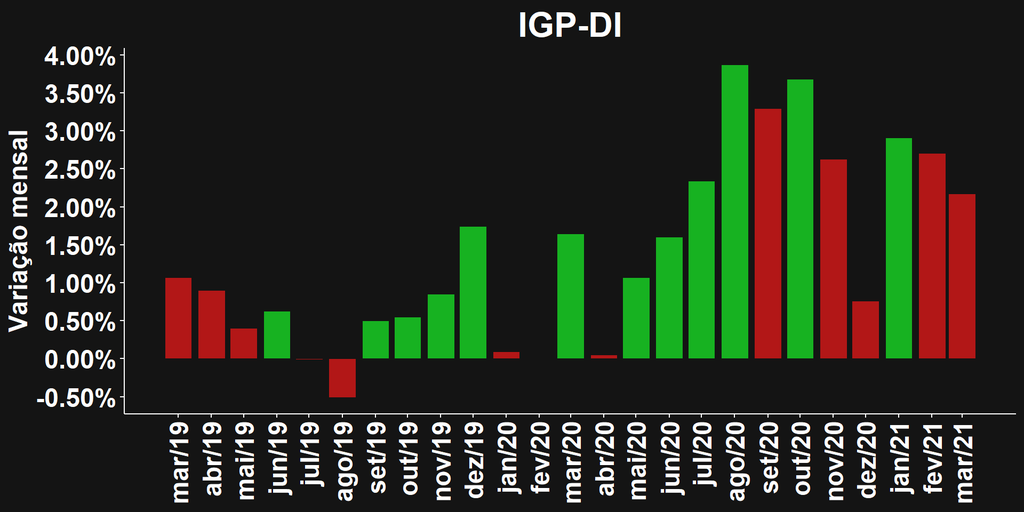

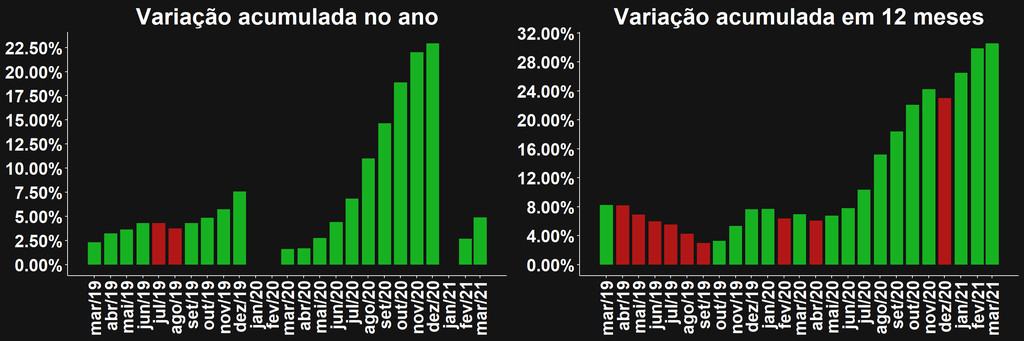

[output not shown]

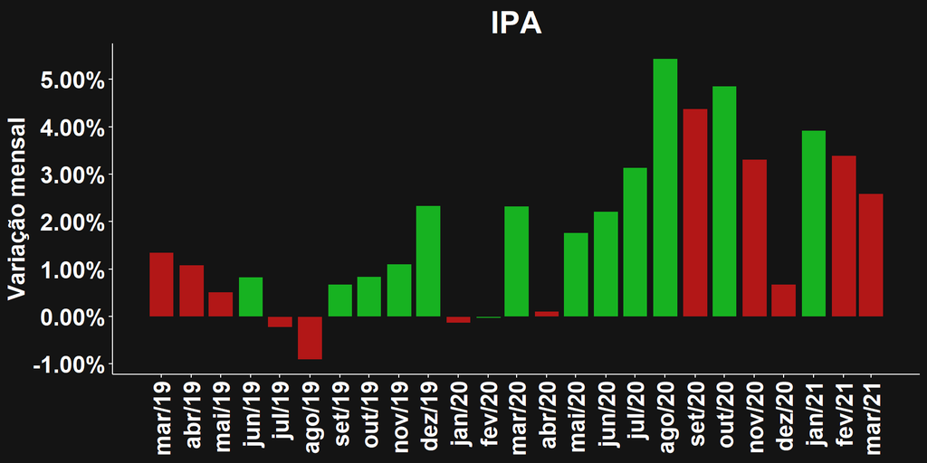

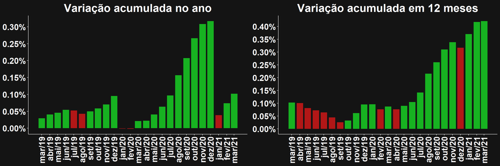

O Indíce de Preços ao Consumidor (IPC), integrante do IGP-DI com peso de 30%, apresentou variação de 1% em março, valor superior ao mesmo período do ano anterior quando apresentou uma taxa de 0.34%. Com esse resultado o indíce acumula no ano uma variação positiva de 1.54%, e em 12 meses uma variação positiva de 6.1%.

|  | 03/2020 | 02/2021 | 03/2021 |
| --- | --- | --- | --- |
| Variação mensal | 0.34% | 0.54% | 1% |
| Variação acumulada no ano | 0.33% | 0.54% | 1.54% |
| Variação acumulada em 12 meses | 3.44% | 5.41% | 6.1% |

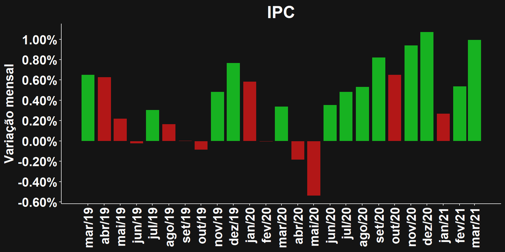

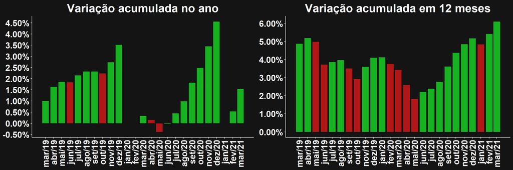

O Indíce Nacional de Custos de Construção (INCC), integrante do IGP-DI com peso de 10%, apresentou variação de 1.3% em março, valor superior ao mesmo período do ano anterior quando apresentou uma taxa de 0.26%. Com esse resultado o indíce acumula no ano uma variação positiva de 3.22%, e em 12 meses uma variação positiva de 12.23%.

|  | 03/2020 | 02/2021 | 03/2021 |
| --- | --- | --- | --- |
| Variação mensal | 0.26% | 1.89% | 1.3% |
| Variação acumulada no ano | 0.59% | 1.89% | 3.22% |
| Variação acumulada em 12 meses | 4.23% | 11.07% | 12.23% |

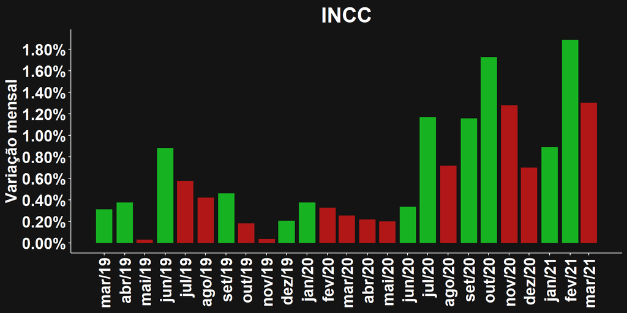

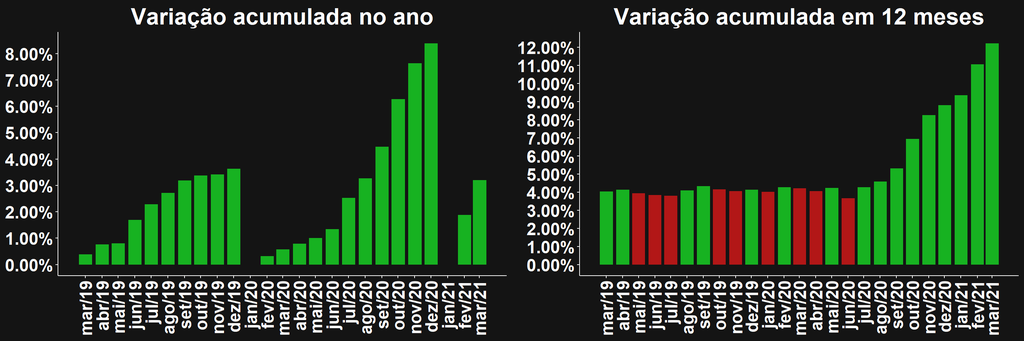

# Estatísticas

As estatísticas descritivas a seguir são feitas com base nos últimos 48 meses, e tem como objetivo possibilitar a avaliação do resultado observado em comparação aos períodos anteriores.

|  | Minimo | 1 Quartil | Mediana | Media | 3 Quartil | Maximo | Desvio Padrão |
| --- | --- | --- | --- | --- | --- | --- | --- |
| IPCA | -0.38% | 0.14% | 0.27% | 0.34% | 0.46% | 1.35% | 0.38% |
| INPC | -0.3% | 0.1% | 0.24% | 0.34% | 0.47% | 1.46% | 0.41% |
| IGP-M | -1.1% | 0.17% | 0.69% | 0.88% | 1.41% | 4.34% | 1.21% |
| IGP-DI | -1.24% | 0.1% | 0.65% | 0.89% | 1.61% | 3.87% | 1.19% |
| IPA | -1.96% | 0.07% | 0.9% | 1.12% | 2.25% | 5.44% | 1.66% |
| IPC | -0.54% | 0.16% | 0.34% | 0.35% | 0.55% | 1.19% | 0.35% |
| INCC | -0.02% | 0.21% | 0.32% | 0.49% | 0.65% | 1.89% | 0.44% |

Levando em consideração o desvio padrão de cada indíce, proporcionalmente os que mais se afastaram da média foram o IPC, o INCC e o IGP-M.

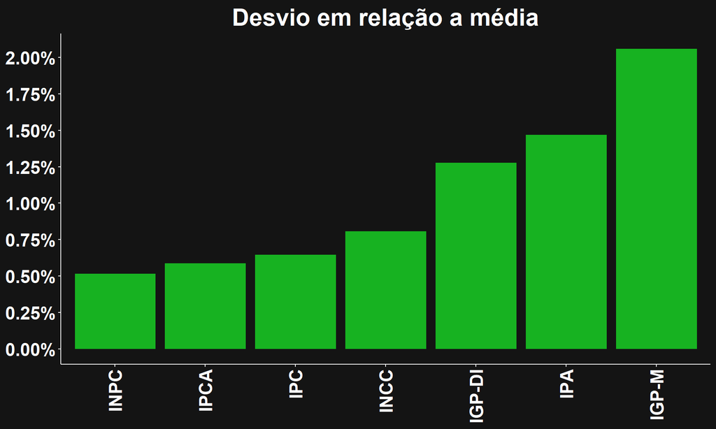

**João Victor Gomes**  
**jvg.santana@gmail.com**  
**[linkedin.com/in/jvictorgomes](https://www.linkedin.com/in/jvictorgomes/)**